# Eighth Week: Text Analysis in R

To be, or not to be

Benyamin Jamialahmadi 94105282

2018-05-08 03:44:38

> با استفاده از بسته gutenberg داده های لازم را به دست آورید و به سوالات زیر پاسخ دهید.

```r
library(tm)
library(dplyr)
```

```r
library(stringr)
library(tidyr)
library(wordcloud2)
library(tidytext)
library(gutenbergr)
library(ngram)
Sys.setenv(JAVA_HOME='C:\\Program Files\\Java\\jdk1.8.0_73/')
library(rJava)
library(qdap)
library(ggplot2)
library(highcharter)
ThePickwickPapers <- gutenberg_download(580)
```

```
## Determining mirror for Project Gutenberg from http://www.gutenberg.org/robot/harvest
```

```
## Using mirror http://aleph.gutenberg.org
```

```r
OliverTwist = gutenberg_download(730)
NicholasNickleby = gutenberg_download(967)
TheOldCuriosityShop = gutenberg_download(700)
BarnabyRudge = gutenberg_download(917)
MartinChuzzlewit = gutenberg_download(968)
DombeyandSon = gutenberg_download(821)
DavidCopperfield =gutenberg_download(766)
BleakHouse =gutenberg_download(1023)
HardTimes =gutenberg_download(786)
LittleDorrit =gutenberg_download(963)
ATaleofTwoCities = gutenberg_download(98)
GreatExpectations = gutenberg_download(1400)
OurMutualFriend = gutenberg_download(883)
TheMysteryofEdwinDrood =gutenberg_download(564)

 books_txt = c(ThePickwickPapers$text,
              OliverTwist$text,
              NicholasNickleby$text,
              TheOldCuriosityShop$text,
              BarnabyRudge$text,
              MartinChuzzlewit$text,
              DombeyandSon$text,
              DavidCopperfield$text,
              BleakHouse$text,
              HardTimes$text,
              LittleDorrit$text,
              ATaleofTwoCities$text,
              GreatExpectations$text,
              GreatExpectations$text,
              OurMutualFriend$text,
              TheMysteryofEdwinDrood$text)

books_list = list(ThePickwickPapers,
             OliverTwist,
             NicholasNickleby,
             TheOldCuriosityShop,
             BarnabyRudge,
             MartinChuzzlewit,
             DombeyandSon,
             DavidCopperfield,
             BleakHouse,
             HardTimes,
             LittleDorrit,
             ATaleofTwoCities,
             GreatExpectations,
             OurMutualFriend,
             TheMysteryofEdwinDrood)

rm(ThePickwickPapers)
rm(OliverTwist)
rm(NicholasNickleby)
rm(TheOldCuriosityShop)
rm(BarnabyRudge)
rm(MartinChuzzlewit)
rm(DombeyandSon)
rm(DavidCopperfield)
rm(BleakHouse)
rm(LittleDorrit)
rm(ATaleofTwoCities)
rm(GreatExpectations)
rm(OurMutualFriend)
rm(TheMysteryofEdwinDrood)
####################
####################functions
####################

splitWord <- function(string){
  string %>%
    str_split(pattern = "\\s+") -> temp
  return(temp)
}

cleanText <- function(string){
  string %>% str_replace_all("\"","") %>%
    str_replace_all("[[:punct:]]"," ") %>% str_replace_all(pattern = "\\s+" , replacement = " ") %>% return()
}

freqText <- function(string){
  string %>% unlist() %>%
    table() %>%
    as.data.frame(stringsAsFactors = F) -> temp
  colnames(temp) <- c('word','count')
  temp %>% filter(str_length(word)>1) %>%
    filter(!str_detect(word,"\\d")) -> temp
  return(temp)
}

removeStopWords <- function(string){
  stopwords_en = stopwords('en')
  stopwords_en = c(stopwords_en,"mr","sir","miss","mrs","s","ll","will")
  stopwords_en1 = stopwords_en
  stopwords_en2 = stopwords_en
  substr(stopwords_en1, 1, 1) <- toupper(substr(stopwords_en1, 1, 1))
  substr(stopwords_en2, 1, 1) <- toupper(stopwords_en2)
  stopwords_en = c(stopwords_en, stopwords_en1, stopwords_en2)
  stopwords_regex = paste(stopwords_en, collapse = '\\b|\\b')
  stopwords_regex = paste0('\\b', stopwords_regex, '\\b')
  string %>% str_remove_all(stopwords_regex) %>%
    return()
}
```

۱. چارلز دیکنز نویسنده معروف انگلیسی بالغ بر چهارده رمان (چهارده و نیم) نوشته است. متن تمامی کتاب های او را دانلود کنید و سپس بیست لغت برتر استفاده شده را به صورت یک نمودار ستونی نمایش دهید. (طبیعتا باید ابتدا متن را پاکسازی کرده و stopping words را حذف نمایید تا به کلماتی که بار معنایی مشخصی منتقل می کنند برسید.)

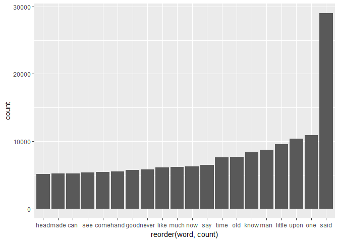

```r
books_txt %>% cleanText() %>% removeStopWords() %>% splitWord() %>% freqText() -> freq_words
cleaned_charles = books_txt %>% cleanText()
freq_words %>% arrange(-count)  %>% filter(row_number() < 21) %>% ggplot(aes(reorder(word,count) ,count)) + geom_bar(stat = "identity")
```

۲. ابر لغات ۲۰۰ کلمه پرتکرار در رمان های چارلز دیکنز را رسم نمایید. این کار را با بسته wordcloud2 انجام دهید. برای دانلود می توانید به لینک زیر مراجعه کنید.

https://github.com/Lchiffon/wordcloud2

با استفاده از عکسی که در ابتدا متن آمده ابر لغاتی مانند شکل زیر رسم کنید. (راهنمایی: از ورودی figpath در دستور wordcloud2 استفاده نمایید.مثالی در زیر آورده شده است.)

```r
t = freq_words %>% arrange(-count) %>% filter(row_number() < 300)
row.names(t) = t$word
t %>% wordcloud2(size = 1,figPath = '../hw_08/images/dickens1_1.png')
```

[interactive chart not shown]

۳. اسم پنج شخصیت اصلی در هر رمان دیکنز را استخراج کنید و با نموداری تعداد دفعات تکرار شده بر حسب رمان را رسم نمایید. (مانند مثال کلاس در رسم اسامی شخصیت ها در سری هر پاتر)

```r
charecters = data.frame(Book = c(),Name = c(), Freq = c())
cleaned_texts = list()
splited_texts = list()
freq_texts = list()
i = 1
for(i in 1:15){
  books_list[[i]]$text %>% cleanText() -> cleaned_texts[[i]]
  cleaned_texts[[i]] %>% removeStopWords() %>% splitWord() -> splited_texts[[i]]
  splited_texts[[i]] %>% freqText() -> freq_texts[[i]]
  freq_texts[[i]] %>% head(5) %>% mutate(Book = books_list[[i]]$text[1]) -> t
  charecters <- rbind(charecters,t)
}
charecters %>% hchart("column",hcaes(x = Book, y = count, group = word))
```

[interactive chart not shown]

۴. در بسته tidytext داده ایی به نام sentiments وجود دارد که فضای احساسی لغات را مشخص می نماید. با استفاده از این داده نمودار ۲۰ لغت برتر negative و ۲۰ لغت برتر positive را در کنار هم رسم نمایید. با استفاده از این نمودار فضای حاکم بر داستان چگونه ارزیابی می کنید؟ (به طور مثال برای کتاب داستان دو شهر فضای احساسی داستان به ترتیب تکرر در نمودار زیر قابل مشاهده است.)

```r
freq_words %>% full_join(sentiments) %>% filter(sentiment == "positive") %>% arrange(-count) %>% filter(!is.na(sentiment) & !is.na(count)) %>% head(20) -> positives
freq_words %>% full_join(sentiments) %>% filter(sentiment == "negative") %>% arrange(-count) %>% filter(!is.na(sentiment) & !is.na(count)) %>% head(20) -> negatives
```

```r
t = rbind(positives,negatives)
t %>% hchart('bar',hcaes(x=word,y=count))
```

[interactive chart not shown]

```r
t = c()

  freq_texts[[1]] %>% full_join(sentiments) %>%
    filter(!is.na(sentiment) & !is.na(count)) %>% group_by(sentiment) %>% summarise(c = sum(count)) %>%
    hchart( type = "bar", hcaes(x = sentiment, y= c)) %>% hc_title(text = books_list[[i]]$text[1])
```

[interactive chart not shown]

```r
    freq_texts[[2]] %>% full_join(sentiments) %>%
    filter(!is.na(sentiment) & !is.na(count)) %>% group_by(sentiment) %>% summarise(c = sum(count)) %>%
    hchart( type = "bar", hcaes(x = sentiment, y= c)) %>% hc_title(text = books_list[[i]]$text[1])
```

[interactive chart not shown]

```r
  freq_texts[[3]] %>% full_join(sentiments) %>%
    filter(!is.na(sentiment) & !is.na(count)) %>% group_by(sentiment) %>% summarise(c = sum(count)) %>%
    hchart( type = "bar", hcaes(x = sentiment, y= c)) %>% hc_title(text = books_list[[i]]$text[1])
```

[interactive chart not shown]

```r
  freq_texts[[4]] %>% full_join(sentiments) %>%
    filter(!is.na(sentiment) & !is.na(count)) %>% group_by(sentiment) %>% summarise(c = sum(count)) %>%
    hchart( type = "bar", hcaes(x = sentiment, y= c)) %>% hc_title(text = books_list[[i]]$text[1])
```

[interactive chart not shown]

```r
  freq_texts[[5]] %>% full_join(sentiments) %>%
    filter(!is.na(sentiment) & !is.na(count)) %>% group_by(sentiment) %>% summarise(c = sum(count)) %>%
    hchart( type = "bar", hcaes(x = sentiment, y= c)) %>% hc_title(text = books_list[[i]]$text[1])
```

[interactive chart not shown]

```r
  freq_texts[[6]] %>% full_join(sentiments) %>%
    filter(!is.na(sentiment) & !is.na(count)) %>% group_by(sentiment) %>% summarise(c = sum(count)) %>%
    hchart( type = "bar", hcaes(x = sentiment, y= c)) %>% hc_title(text = books_list[[i]]$text[1])
```

[interactive chart not shown]

```r
  freq_texts[[7]] %>% full_join(sentiments) %>%
    filter(!is.na(sentiment) & !is.na(count)) %>% group_by(sentiment) %>% summarise(c = sum(count)) %>%
    hchart( type = "bar", hcaes(x = sentiment, y= c)) %>% hc_title(text = books_list[[i]]$text[1])
```

[interactive chart not shown]

```r
  freq_texts[[8]] %>% full_join(sentiments) %>%
    filter(!is.na(sentiment) & !is.na(count)) %>% group_by(sentiment) %>% summarise(c = sum(count)) %>%
    hchart( type = "bar", hcaes(x = sentiment, y= c)) %>% hc_title(text = books_list[[i]]$text[1])
```

[interactive chart not shown]

```r
  freq_texts[[9]] %>% full_join(sentiments) %>%
    filter(!is.na(sentiment) & !is.na(count)) %>% group_by(sentiment) %>% summarise(c = sum(count)) %>%
    hchart( type = "bar", hcaes(x = sentiment, y= c)) %>% hc_title(text = books_list[[i]]$text[1])
```

[interactive chart not shown]

```r
  freq_texts[[10]] %>% full_join(sentiments) %>%
    filter(!is.na(sentiment) & !is.na(count)) %>% group_by(sentiment) %>% summarise(c = sum(count)) %>%
    hchart( type = "bar", hcaes(x = sentiment, y= c)) %>% hc_title(text = books_list[[i]]$text[1])
```

[interactive chart not shown]

```r
  freq_texts[[11]] %>% full_join(sentiments) %>%
    filter(!is.na(sentiment) & !is.na(count)) %>% group_by(sentiment) %>% summarise(c = sum(count)) %>%
    hchart( type = "bar", hcaes(x = sentiment, y= c)) %>% hc_title(text = books_list[[i]]$text[1])
```

[interactive chart not shown]

```r
  freq_texts[[12]] %>% full_join(sentiments) %>%
    filter(!is.na(sentiment) & !is.na(count)) %>% group_by(sentiment) %>% summarise(c = sum(count)) %>%
    hchart( type = "bar", hcaes(x = sentiment, y= c)) %>% hc_title(text = books_list[[i]]$text[1])
```

[interactive chart not shown]

```r
  freq_texts[[13]] %>% full_join(sentiments) %>%
    filter(!is.na(sentiment) & !is.na(count)) %>% group_by(sentiment) %>% summarise(c = sum(count)) %>%
    hchart( type = "bar", hcaes(x = sentiment, y= c)) %>% hc_title(text = books_list[[i]]$text[1])
```

[interactive chart not shown]

```r
  freq_texts[[14]] %>% full_join(sentiments) %>%
    filter(!is.na(sentiment) & !is.na(count)) %>% group_by(sentiment) %>% summarise(c = sum(count)) %>%
    hchart( type = "bar", hcaes(x = sentiment, y= c)) %>% hc_title(text = books_list[[i]]$text[1])
```

[interactive chart not shown]

```r
  freq_texts[[15]] %>% full_join(sentiments) %>%
    filter(!is.na(sentiment) & !is.na(count)) %>% group_by(sentiment) %>% summarise(c = sum(count)) %>%
    hchart( type = "bar", hcaes(x = sentiment, y= c)) %>% hc_title(text = books_list[[i]]$text[1])
```

[interactive chart not shown]

۵. متن داستان بینوایان را به ۲۰۰ قسمت مساوی تقسیم کنید. برای هر قسمت تعداد لغات positive و negative را حساب کنید و سپس این دو سری زمانی را در کنار هم برای مشاهده فضای احساسی داستان رسم نمایید.

```r
LesMiserable = gutenberg_download(135)
LesMiserable$text %>% cleanText() %>% removeStopWords() -> temp
len = ceiling(length(temp)/200)
chunckedtemp = split(temp, ceiling((seq(length(temp)))/ len))
P = c()
N = c()
i = 1
chunk = data.frame()
for (t in chunckedtemp){
  t %>% splitWord() %>% freqText() %>% full_join(sentiments,by = 'word') %>% filter(!is.na(sentiment) , !is.na(count)) %>%
    group_by(sentiment) %>% summarise(count = sum(count)) %>% filter(sentiment == "positive" | sentiment == "negative") %>% mutate(ch = i) -> t1
  chunk = rbind(chunk,t1)
  i = i + 1
}
chunk %>% hchart(type = "line",hcaes(x = ch, y = count, group = sentiment))
```

[interactive chart not shown]

۶. ابتدا ترکیبات دوتایی کلماتی که پشت سر هم می آیند را استخراج کنید و سپس نمودار ۳۰ جفت لغت پرتکرار را رسم نمایید.

```r
data.frame(text = c(books_txt %>% cleanText() %>% removeStopWords()))  %>% unnest_tokens(bigram, text, token = "ngrams", n = 2) %>%
  separate(bigram, c("First", "Second"), sep = " ") -> t
t %>% group_by(First, Second) %>%
  summarise(count = n()) %>% arrange(-count) %>% head(30) %>% mutate(word = paste(First, Second))  %>%
  hchart("bar", hcaes(x = word, y = count))
```

[interactive chart not shown]

۷. جفت کلماتی که با she و یا he آغاز می شوند را استخراج کنید. بیست فعل پرتکراری که زنان و مردان در داستان های دیکنز انجام می دهند را استخراج کنید و نمودار آن را رسم نمایید.

```r
t %>% filter(First == "he" | First == "He") %>% filter(!Second %in% stopwords()) %>% group_by(Second) %>% summarise(count = n()) -> he
t %>% filter(First == "she" | First == "She") %>% filter(!Second %in% stopwords()) %>% group_by(Second) %>% summarise(count = n()) -> she
he %>% hchart("bar",hcaes(x = Second,y = count))
```

[interactive chart not shown]

```r
she %>% hchart("bar",hcaes(x = Second,y = count))
```

[interactive chart not shown]

۸. برای کتاب های دیکنز ابتدا هر فصل را جدا کنید. سپی برای هر فصل 1-gram, 2-gram را استخراج کنید. آیا توزیع N-gram در کارهای دیکنز یکسان است؟ با رسم نمودار هم این موضوع را بررسی کنید.

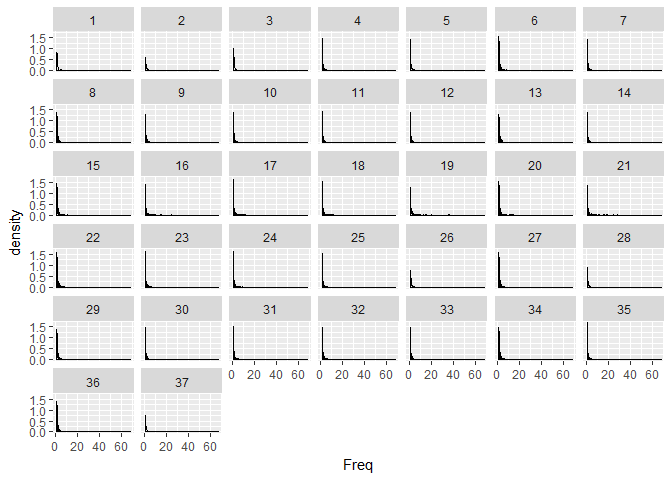

```r
HardTimes1 <- HardTimes$text %>% cleanText() %>% removeStopWords() %>% .[122:length(HardTimes$text)] %>%
  paste( collapse = ' ') %>% str_split(pattern = "\\bCHAPTER\\b") %>% .[[1]]
gram1 = data.frame()
gram2 = data.frame()
for(i in 1:37){
  gram1 = data.frame(text = HardTimes1[i]) %>% unnest_tokens(word, text, token = "ngrams", n = 1) %>% table() %>% as.data.frame(stringsAsFactors = F) %>% mutate(ch = i) %>% rbind(gram1)
  gram2 = data.frame(text = HardTimes1[i]) %>% unnest_tokens(word, text, token = "ngrams", n = 2) %>% table() %>% as.data.frame(stringsAsFactors = F) %>% mutate(ch = i) %>% rbind(gram2)
}
ggplot(gram1,aes(Freq)) + geom_density() + facet_wrap(~ch)
```

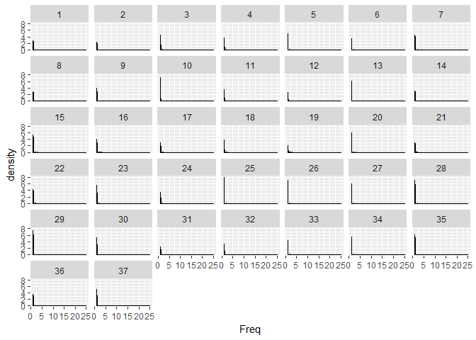

```r
ggplot(gram2,aes(Freq)) + geom_density() + facet_wrap(~ch)
```

```r
aov(Freq ~ as.factor(ch), data = gram1) %>% summary.aov()
```

```
##                  Df Sum Sq Mean Sq F value Pr(>F)
## as.factor(ch)    36    854  23.715   4.347 <2e-16 ***
## Residuals     27562 150376   5.456
## ---
## Signif. codes:  0 '***' 0.001 '**' 0.01 '*' 0.05 '.' 0.1 ' ' 1
```

```r
aov(Freq ~ as.factor(ch), data = gram2) %>% summary.aov()
```

```
##                  Df Sum Sq Mean Sq F value   Pr(>F)
## as.factor(ch)    36     17  0.4768   2.351 8.68e-06 ***
## Residuals     46234   9375  0.2028
## ---
## Signif. codes:  0 '***' 0.001 '**' 0.01 '*' 0.05 '.' 0.1 ' ' 1
```

۹. برای آثار ارنست همینگوی نیز تمرین ۸ را تکرار کنید. آیا بین آثار توزیع n-grams در بین آثار این دو نویسنده یکسان است؟

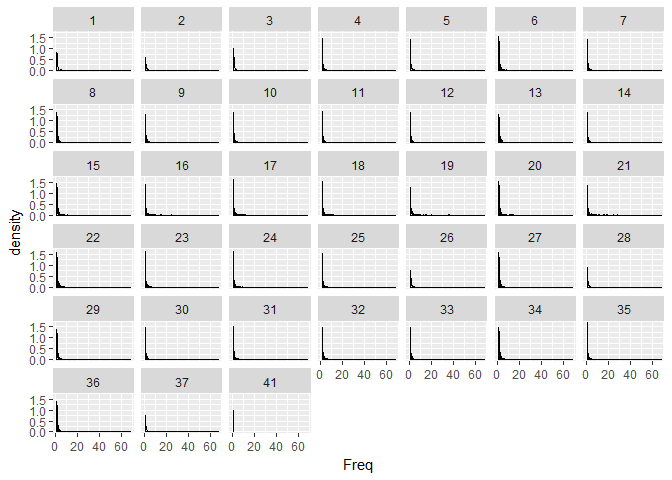

```r
WildJustice = gutenberg_download(152)
WildJustice1 <- WildJustice$text %>% cleanText() %>% removeStopWords() %>% .[229:length(HardTimes$text)] %>%
  paste( collapse = ' ') %>% str_split(pattern = "\\bChapter\\b") %>% .[[1]]
gram3 = data.frame()
gram4 = data.frame()
for(i in 1:41){
  gram3 = data.frame(text = HardTimes1[i]) %>% unnest_tokens(word, text, token = "ngrams", n = 1) %>% table() %>% as.data.frame(stringsAsFactors = F) %>% mutate(ch = i) %>% rbind(gram1)
  gram4 = data.frame(text = HardTimes1[i]) %>% unnest_tokens(word, text, token = "ngrams", n = 2) %>% table() %>% as.data.frame(stringsAsFactors = F) %>% mutate(ch = i) %>% rbind(gram2)
}
ggplot(gram3,aes(Freq)) + geom_density() + facet_wrap(~ch)
```

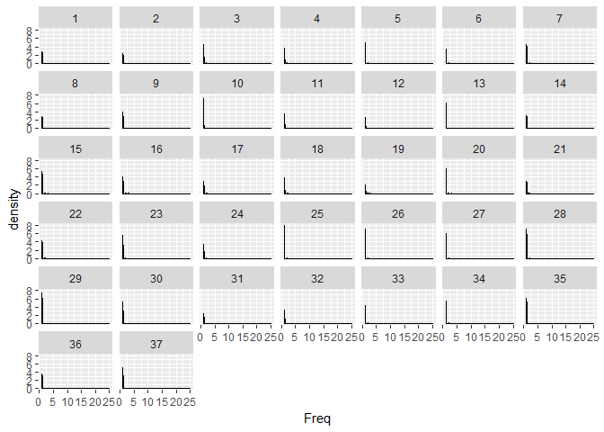

```r
ggplot(gram4,aes(Freq)) + geom_density() + facet_wrap(~ch)
```

```r
aov(Freq ~ as.factor(ch), data = gram3) %>% summary.aov()
```

```
##                  Df Sum Sq Mean Sq F value Pr(>F)
## as.factor(ch)    37    854  23.090   4.232 <2e-16 ***
## Residuals     27562 150376   5.456
## ---
## Signif. codes:  0 '***' 0.001 '**' 0.01 '*' 0.05 '.' 0.1 ' ' 1
```

```r
aov(Freq ~ as.factor(ch), data = gram4) %>% summary.aov()
```

```
##                  Df Sum Sq Mean Sq F value   Pr(>F)
## as.factor(ch)    36     17  0.4768   2.351 8.68e-06 ***
## Residuals     46234   9375  0.2028
## ---
## Signif. codes:  0 '***' 0.001 '**' 0.01 '*' 0.05 '.' 0.1 ' ' 1
```

```r
t.test(gram1$Freq,gram3$Freq)
```

```
##
##  Welch Two Sample t-test
##
## data:  gram1$Freq and gram3$Freq
## t = 0.0014035, df = 55197, p-value = 0.9989
## alternative hypothesis: true difference in means is not equal to 0
## 95 percent confidence interval:
##  -0.03902898  0.03908491
## sample estimates:
## mean of x mean of y
##  1.771876  1.771848
```

```r
t.test(gram2$Freq,gram4$Freq)
```

```
##
##  Welch Two Sample t-test
##
## data:  gram2$Freq and gram4$Freq
## t = 0, df = 92540, p-value = 1
## alternative hypothesis: true difference in means is not equal to 0
## 95 percent confidence interval:
##  -0.005805732  0.005805732
## sample estimates:
## mean of x mean of y
##  1.056061  1.056061
```

۱۰. بر اساس دادهایی که در تمرین ۸ و ۹ از آثار دو نویسنده به دست آوردید و با استفاده از N-gram ها یک مدل لاجستیک برای تشخیص صاحب اثر بسازید. خطای مدل چقدر است؟ برای یادگیری مدل از کتاب کتاب الیور تویست اثر دیکنز و کتاب پیرمرد و دریا استفاده نکنید. پس از ساختن مدل برای تست کردن فصل های این کتابها را به عنوان داده ورودی به مدل بدهید. خطای تشخیص چقدر است؟

```r
library(h2o)
h2o.init()
```

[output not shown]

```r
t = rbind(gram1 %>% mutate(author = 1,ngram = 1),gram2 %>% mutate(author = 1,ngram = 2),gram3 %>% mutate(author = 2,ngram = 1),gram4 %>% mutate(author = 2,ngram = 2))
t$author = as.factor(t$author)
ht <- as.h2o(t)
chglm = h2o.glm(y = "author", x = colnames(t),
                training_frame =  ht , family="binomial",nfolds = 5)
chglm
```

```
## Model Details:
## ==============
##
## H2OBinomialModel: glm
## Model ID:  GLM_model_R_1525737118712_1
## GLM Model: summary
##     family  link                                regularization
## 1 binomial logit Elastic Net (alpha = 0.5, lambda = 1.376E-8 )
##   number_of_predictors_total number_of_active_predictors
## 1                          3                           3
##   number_of_iterations training_frame
## 1                    1              t
##
## Coefficients: glm coefficients
##       names coefficients standardized_coefficients
## 1 Intercept     0.000028                  0.000014
## 2      Freq    -0.000004                 -0.000006
## 3        ch     0.000002                  0.000026
## 4     ngram    -0.000036                 -0.000018
##
## H2OBinomialMetrics: glm
## ** Reported on training data. **
##
## MSE:  0.25
## RMSE:  0.5
## LogLoss:  0.6931472
## Mean Per-Class Error:  0.5
## AUC:  0.5000196
## Gini:  3.924956e-05
## R^2:  2.787819e-10
## Residual Deviance:  204812.5
## AIC:  204820.5
##
## Confusion Matrix (vertical: actual; across: predicted) for F1-optimal threshold:
##        1      2    Error           Rate
## 1      0  73870 1.000000   =73870/73870
## 2      0  73871 0.000000       =0/73871
## Totals 0 147741 0.499997  =73870/147741
##
## Maximum Metrics: Maximum metrics at their respective thresholds
```

[output cut: 62 more lines]

```
## ---
##                            mean           sd    cv_1_valid   cv_2_valid
## precision             0.5000183 0.0012364608     0.5027954   0.49765494
## r2                -4.0331837E-5 1.7212667E-5 -5.9915586E-5 -3.665518E-5
## recall               0.99998647 1.9156296E-5           1.0          1.0
## residual_deviance     40963.332     134.8429      40914.55     41086.04
## rmse                 0.50000703 4.3206487E-6    0.50000715   0.50000364
## specificity        5.4182186E-5  7.662518E-5           0.0          0.0
##                     cv_3_valid    cv_4_valid   cv_5_valid
## precision            0.5007673      0.498823    0.5000508
## r2                -6.426862E-6 -2.4288722E-5 -7.437284E-5
## recall                     1.0           1.0    0.9999323
## residual_deviance    40653.203     41223.406     40939.47
## rmse                  0.500001     0.5000047    0.5000186
## specificity                0.0           0.0 2.7091094E-4
```

50 درصد خطا وجود دارد.